# Bellabeat App Usage analysis

Chukuneke Chinemerem Chuks

11/16/2022

## Introduction and background

This is one of the two Capstone-Project-Case-Studies for the Google Data Analytics Certificate Program which aims to solve real world types of business problems using data analytics. This markdown document follows and applies the Ask-Prepare-Process-Analyze-Share-Act framework as a methodical approach to addressing the key areas of consideration within the data analysis process.

## About the company

Urška Sršen and Sando Mur founded Bellabeat, a high-tech company that manufactures health-focused smart products. Sršen used her background as an artist to develop beautifully designed technology that informs and inspires women around the world. Collecting data on activity, sleep, stress, and reproductive health has allowed Bellabeat to empower women with knowledge about their own health and habits. Since it was founded in 2013, Bellabeat has grown rapidly and quickly positioned itself as a tech-driven wellness company for women.

By 2016, Bellabeat had opened offices around the world and launched multiple products. Bellabeat products became available through a growing number of online retailers in addition to their own e-commerce channel on their website. The company has invested in traditional advertising media, such as radio, out-of-home billboards, print, and television, but focuses on digital marketing extensively. Bellabeat invests year-round in Google Search, maintaining active Facebook and Instagram pages, and consistently engages consumers on Twitter. Additionally, Bellabeat runs video ads on Youtube and display ads on the Google Display Network to support campaigns around key marketing dates.

## Business question

Sršen knows that an analysis of Bellabeat’s available consumer data would reveal more opportunities for growth. She has asked the marketing analytics team to focus on a Bellabeat product and analyze smart device usage data in order to gain insight into how people are already using their smart devices. Then, using this information, she would like high-level recommendations for how these trends can inform Bellabeat marketing strategy

## Prepare the data

### Upload CSV files

We upload our CSV files to our project from the relevant data source: https://www.kaggle.com/arashnic/fitbit

### Installing and loading common packages and libraries

We can always install and load packages along the way as you may discover we need different packages after we start our analysis.

### Loading CSV files

Here we’ll create several dataframes that are useful for this project. daily activity

```r
daily_activity <- read.csv("dailyActivity_merged.csv")
```

sleep data

```r
sleep_day <- read.csv("sleepDay_merged.csv")
```

daily calories

```r
daily_calories <- read.csv("dailyCalories_merged.csv")
```

intensities

```r
daily_intensity <- read.csv("dailyIntensities_merged.csv")
```

daily steps

```r
daily_steps <- read.csv("dailySteps_merged.csv")
```

Quickly view one of our data Take a look at the daily_activity data.

```r
colnames(daily_activity)
```

```
##  [1] "Id"                       "ActivityDate"
##  [3] "TotalSteps"               "TotalDistance"
##  [5] "TrackerDistance"          "LoggedActivitiesDistance"
##  [7] "VeryActiveDistance"       "ModeratelyActiveDistance"
##  [9] "LightActiveDistance"      "SedentaryActiveDistance"
## [11] "VeryActiveMinutes"        "FairlyActiveMinutes"
## [13] "LightlyActiveMinutes"     "SedentaryMinutes"
## [15] "Calories"
```

Take a look at the sleep_day data.

```r
colnames(sleep_day)
```

```
## [1] "Id"                 "SleepDay"           "TotalSleepRecords"
## [4] "TotalMinutesAsleep" "TotalTimeInBed"
```

## Process the data

First, understanding some summary statistics How many unique participants are there in each dataframe? For example, it looks like there may be more participants in the daily activity dataset than the sleep dataset.

Load the tidyverse library to manipulate the data

```r
library(tidyverse)
n_distinct(daily_activity$Id)
```

```
## [1] 33
```

```r
n_distinct(sleep_day$Id)
```

```
## [1] 24
```

```r
n_distinct(daily_calories$Id)
```

```
## [1] 33
```

```r
n_distinct(daily_intensity)
```

```
## [1] 940
```

```r
n_distinct(daily_steps)
```

```
## [1] 940
```

How many observations are there in each dataframe?

```r
nrow(daily_activity)
```

```
## [1] 940
```

```r
nrow(sleep_day)
```

```
## [1] 413
```

```r
nrow(daily_calories)
```

```
## [1] 940
```

```r
nrow(daily_intensity)
```

```
## [1] 940
```

```r
nrow(daily_steps)
```

```
## [1] 940
```

Check for duplicates

```r
sum(duplicated(daily_activity))
```

```
## [1] 0
```

```r
sum(duplicated(sleep_day))
```

```
## [1] 3
```

```r
sum(duplicated(daily_calories))
```

```
## [1] 0
```

```r
sum(duplicated(daily_intensity))
```

```
## [1] 0
```

```r
sum(duplicated(daily_steps))
```

```
## [1] 0
```

We observe 3 duplicates in the sleep_day data we have to drop those duplicates, using Base R, we call the new dataframe sleepday1 to keep it unique.

```r
sleep_day1 <- sleep_day [!duplicated(sleep_day), ]
```

Now Re check for the duplicates

```r
sum(duplicated(sleep_day1))
```

```
## [1] 0
```

Now we check for NA or NULL columns

```r
sum(is.na(daily_activity))
```

```
## [1] 0
```

```r
sum(is.na(daily_calories))
```

```
## [1] 0
```

```r
sum(is.na(daily_intensity))
```

```
## [1] 0
```

```r
sum(is.na(daily_steps))
```

```
## [1] 0
```

```r
sum(is.na(sleep_day1))
```

```
## [1] 0
```

Quick summary on some dataframes of interest, including the mean, max and minimum values For the daily activity dataframe:

```r
daily_activity %>%
  select(TotalSteps,
         TotalDistance,
         SedentaryMinutes) %>%
  summary()
```

```
##    TotalSteps    TotalDistance    SedentaryMinutes
##  Min.   :    0   Min.   : 0.000   Min.   :   0.0
##  1st Qu.: 3790   1st Qu.: 2.620   1st Qu.: 729.8
##  Median : 7406   Median : 5.245   Median :1057.5
##  Mean   : 7638   Mean   : 5.490   Mean   : 991.2
##  3rd Qu.:10727   3rd Qu.: 7.713   3rd Qu.:1229.5
##  Max.   :36019   Max.   :28.030   Max.   :1440.0
```

For the sleep dataframe:

```r
sleep_day1 %>%
  select(TotalSleepRecords, SleepDay,
  TotalMinutesAsleep,
  TotalTimeInBed) %>%
  summary()
```

```
##  TotalSleepRecords   SleepDay         TotalMinutesAsleep TotalTimeInBed
##  Min.   :1.00      Length:410         Min.   : 58.0      Min.   : 61.0
##  1st Qu.:1.00      Class :character   1st Qu.:361.0      1st Qu.:403.8
##  Median :1.00      Mode  :character   Median :432.5      Median :463.0
##  Mean   :1.12                         Mean   :419.2      Mean   :458.5
##  3rd Qu.:1.00                         3rd Qu.:490.0      3rd Qu.:526.0
##  Max.   :3.00                         Max.   :796.0      Max.   :961.0
```

For the daily calories

```r
daily_calories %>%
  select(ActivityDay,Calories) %>%
  summary()
```

```
##  ActivityDay           Calories
##  Length:940         Min.   :   0
##  Class :character   1st Qu.:1828
##  Mode  :character   Median :2134
##                     Mean   :2304
##                     3rd Qu.:2793
##                     Max.   :4900
```

## Analysis and Visualizations of our data

Plotting a few explorations to confirm some trends and correllations

The visualizations below, gives us a clear indication that more physical movements lead to more calories being burnt, and better sleep. A user whose goal is to burn more calories on a daily basis and enjoy all the benefits of healthy sleep will want to increase how active they are

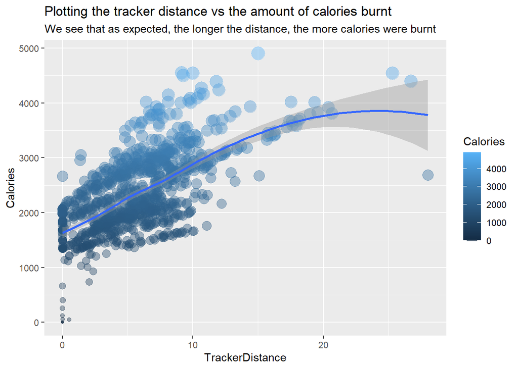

```r
ggplot(daily_activity, aes(TrackerDistance, Calories, size = Calories, color = Calories)) + geom_point(alpha = 0.4)+ guides(size = "none")+ geom_smooth(method = loess) + labs(title = "Plotting the tracker distance vs the amount of calories burnt", subtitle = "We see that as expected, the longer the distance, the more calories were burnt")
```

The correlation between our active users and the medically recommended amount of sleep the recommended sleep average for an adult is between 7 to 9 hours. its is highly recommended to get this complete amount every day as only 23% maximum amount is spent in “deep sleep” which is not only specially important for general wellness, but as well as when the body renews itself.

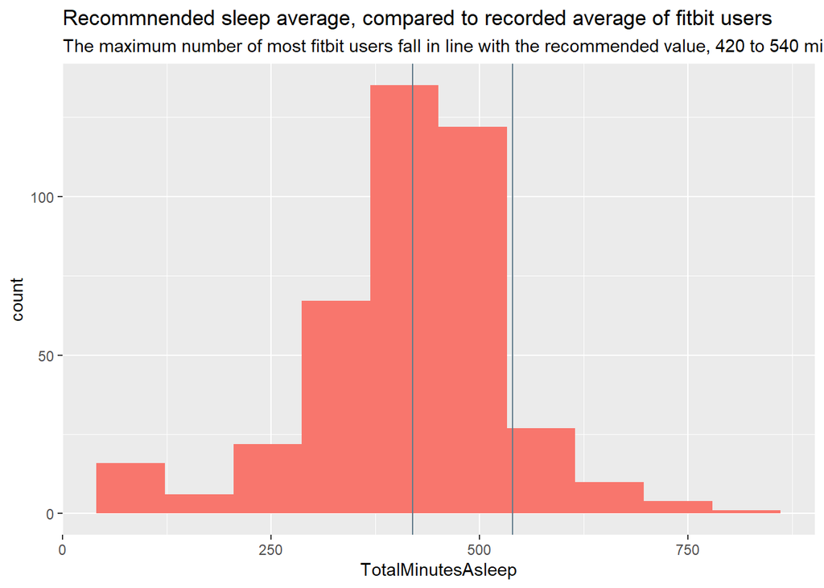

```r
ggplot(sleep_day1, aes(x = TotalMinutesAsleep, fill = "orangered3")) + geom_histogram(bins = 10)+
geom_vline(xintercept = 420, linetype = "solid", color = "lightskyblue4")+
  geom_vline(xintercept = 540, linetype = "solid", color = "lightskyblue4")+
  labs(title = "Recommnended sleep average, compared to recorded average of fitbit users",
       subtitle= "The maximum number of most fitbit users fall in line with the recommended value, 420 to 540 minutes")+ guides(fill = "none")
```

We see that even if many users sleep the required amount, a large amount of users still sleep a little less than that amount.

Loading dpyr package for further manipulations of our data set.

```r
library(dplyr)
library(lubridate)
```

Rename the column for dates to merge based on its variable

```r
sleep_day1 <- sleep_day %>%
  rename(date = SleepDay )
```

Unify the format for dates as mm/dd/yyyy to merge sleep and daily activity data

```r
sleep_day1 <- sleep_day1 %>%
  mutate(date = as.Date(date, format = "%m/%d/%y" ))
```

```r
daily_activity1 <- daily_activity %>%
  rename(date = ActivityDate)
```

```r
daily_activity1 <- daily_activity1 %>%
  mutate(date = as.Date(date, format = "%m/%d/%y" ))
```

```r
colnames(daily_activity1)
```

```
##  [1] "Id"                       "date"
##  [3] "TotalSteps"               "TotalDistance"
##  [5] "TrackerDistance"          "LoggedActivitiesDistance"
##  [7] "VeryActiveDistance"       "ModeratelyActiveDistance"
##  [9] "LightActiveDistance"      "SedentaryActiveDistance"
## [11] "VeryActiveMinutes"        "FairlyActiveMinutes"
## [13] "LightlyActiveMinutes"     "SedentaryMinutes"
## [15] "Calories"
```

Now merge both sleep_day1 and daily activity by date and Id columns

```r
sleepActivity1 <- merge(daily_activity1, sleep_day1, by = c("date","Id"))
```

Now see sleepActivity combined data

```r
colnames(sleepActivity1)
```

```
##  [1] "date"                     "Id"
##  [3] "TotalSteps"               "TotalDistance"
##  [5] "TrackerDistance"          "LoggedActivitiesDistance"
##  [7] "VeryActiveDistance"       "ModeratelyActiveDistance"
##  [9] "LightActiveDistance"      "SedentaryActiveDistance"
## [11] "VeryActiveMinutes"        "FairlyActiveMinutes"
## [13] "LightlyActiveMinutes"     "SedentaryMinutes"
## [15] "Calories"                 "TotalSleepRecords"
## [17] "TotalMinutesAsleep"       "TotalTimeInBed"
```

Plotting a scatter plot to confirm the correllation between sedentary minutes and the total minutes asleep

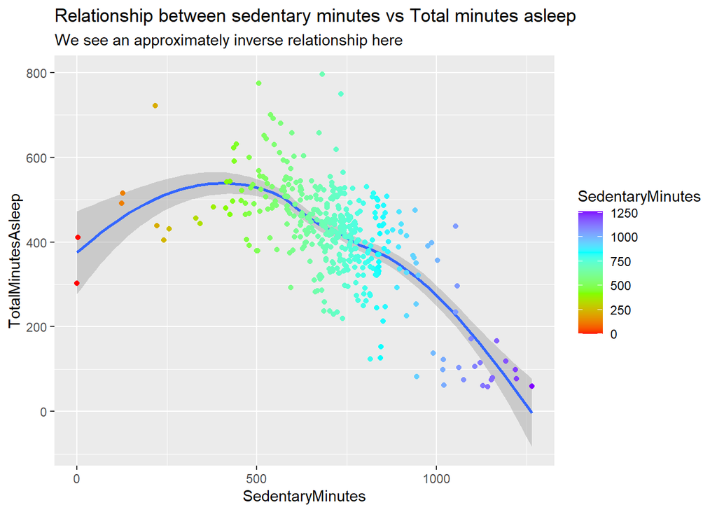

```r
sleepActivity1 %>%
  ggplot(aes(SedentaryMinutes, TotalMinutesAsleep, color = SedentaryMinutes))+ geom_point(alpha = 0.3)+ geom_smooth(method = loess) + geom_point()+
  scale_colour_gradientn(colours=rainbow(4)) + guides(size = "none") +  labs(title = "Relationship between sedentary minutes vs Total minutes asleep", subtitle = "We see an approximately inverse relationship here")
```

Lets create a column called total active minutes to check the correlation between that and the total minutes spent asleep

```r
sleepActivity1 <- sleepActivity1 %>%
  rowwise() %>%
  mutate(TotalActiveMinutes = sum(c(LightlyActiveMinutes, FairlyActiveMinutes, VeryActiveMinutes)))
```

View the sleep_activity dataset

```r
colnames(sleepActivity1)
```

```
##  [1] "date"                     "Id"
##  [3] "TotalSteps"               "TotalDistance"
##  [5] "TrackerDistance"          "LoggedActivitiesDistance"
##  [7] "VeryActiveDistance"       "ModeratelyActiveDistance"
##  [9] "LightActiveDistance"      "SedentaryActiveDistance"
## [11] "VeryActiveMinutes"        "FairlyActiveMinutes"
## [13] "LightlyActiveMinutes"     "SedentaryMinutes"
## [15] "Calories"                 "TotalSleepRecords"
## [17] "TotalMinutesAsleep"       "TotalTimeInBed"
## [19] "TotalActiveMinutes"
```

Plotting our total minutes asleep vs several parameters recorded by our fitbit device

[figure not shown]

```r
sleepActivity1 %>%
  ggplot(aes(TotalActiveMinutes, TotalMinutesAsleep, color = TotalActiveMinutes, size = TotalActiveMinutes))+ geom_point(alpha = 0.7) +
geom_hline(yintercept = 420, linetype = "dashed", color = "black") +
geom_hline(yintercept = 540, linetype = "dashed", color = "black")+  scale_colour_gradientn(colours=rainbow(4)) + guides(size = "none")+ labs(title = "Total active minutes vs total minutes asleep", subtitle = "On average the more active a user, the better the sleep")
```

Tracker distance vs total minutes asleep

[figure not shown]

```r
sleepActivity1 %>%
  ggplot(aes(TrackerDistance, TotalMinutesAsleep, color = TrackerDistance, size = TrackerDistance))+ geom_point(alpha = 0.4) +
geom_hline(yintercept = 420, linetype = "solid", color = "black") +
geom_hline(yintercept = 540, linetype = "solid", color = "black")+  scale_colour_gradientn(colours=rainbow(4)) + guides(size = "none")+ labs(title = "Tracker distance vs total minutes asleep", subtitle = "On average the more active a user, the better the sleep")
```

Now exploring the relationship between various activities recorded by our device vs the calories burnt in the process

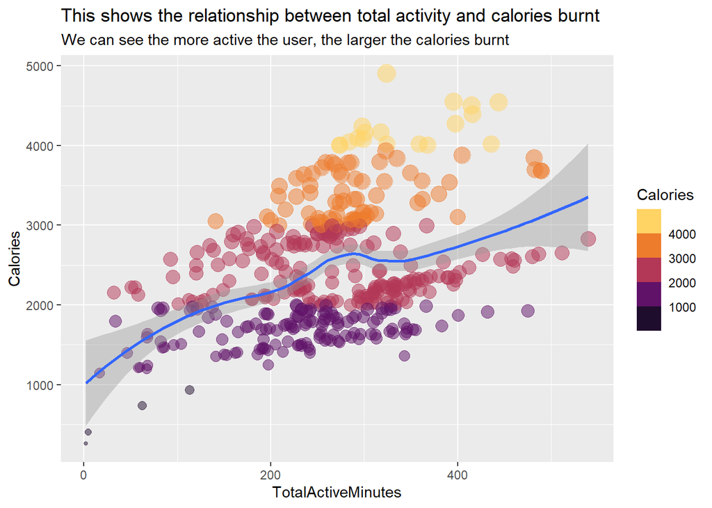

```r
ggplot(sleepActivity1, aes(TotalActiveMinutes, Calories, color= Calories, size = Calories)) + geom_point(alpha = 0.5) + geom_smooth(method = loess)+
  scale_color_viridis_b(option = "B")+ guides(size = "none")+
  labs(title = "This shows the relationship between total activity and calories burnt",
       subtitle = "We can see the more active the user, the larger the calories burnt")
```

For very active distance

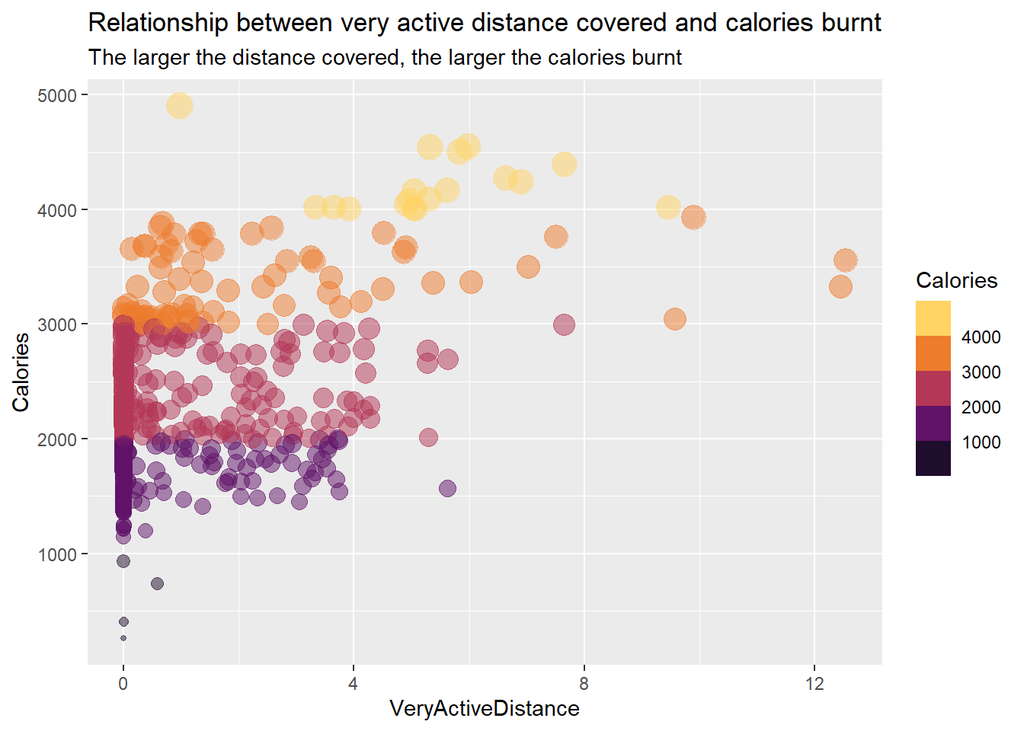

```r
ggplot(data = sleepActivity1, aes(VeryActiveDistance, Calories, color= Calories, size = Calories) )+
scale_color_viridis_b(option = "B")+
  geom_point(alpha = 0.5) + guides(size = "none")+
  labs(title ="Relationship between very active distance covered and calories burnt",
       subtitle = "The larger the distance covered, the larger the calories burnt ")
```

The above graphcal relationships show that apart from sedentary minutes, the longer customers use our devices the more calories they are able to shed at that given time. of course this variable depends on how obese that user is in the first place, more obese users will shed more, hence the outliers in our visualization.